# individual1

Connor Toliver

3/21/2020

```r
library(readxl)
library(tidyverse)
```

```r
defense <- read_excel('cyclonesFootball2019.xlsx', sheet='Defensive')
offense <- read_excel('cyclonesFootball2019.xlsx', sheet='Offensive')
biography <- read_excel('cyclonesFootball2019.xlsx', sheet='Biography')
```

```r
defClean <- defense %>%
  mutate_at(c('Name', 'Opponent_Opponent'), factor)

offClean <- offense %>%
  mutate_at(c('Name', 'Opponent_Opponent'), factor)

bioClean <- biography %>%
  mutate_at(c('Name', 'Hometown', 'Highschool', 'Position', 'Class'), factor)
```

```r
defClean <- defClean %>%
  mutate_at(c(3:11), as.numeric)

offClean <- offClean %>%
  mutate_at(c(3:12), as.numeric)
bioClean <- bioClean %>%
  mutate(temp1 = as.numeric(substring(Height, 1, 1))) %>%
  mutate(temp2 = as.numeric(substring(Height, 3))) %>%
  mutate(Height = (temp1 * 12) + temp2) %>%
  mutate(temp1 = NULL) %>%
  mutate(temp2 = NULL)

str(bioClean)
```

```
## Classes 'tbl_df', 'tbl' and 'data.frame':    105 obs. of  7 variables:
##  $ Name      : Factor w/ 105 levels "Akers, Landen",..: 1 2 3 4 5 6 7 8 9 10 ...
##  $ Position  : Factor w/ 14 levels "Deep Snapper",..: 14 13 14 9 2 3 3 4 4 11 ...
##  $ Height    : num  72 79 77 72 72 75 74 74 72 78 ...
##  $ Weight    : chr  "188" "245" "204" "195" ...
##  $ Class     : Factor w/ 8 levels "Freshman","Junior",..: 5 5 3 5 5 4 5 5 2 1 ...
##  $ Hometown  : Factor w/ 86 levels "Akron, Ohio",..: 16 54 73 50 36 20 41 41 86 14 ...
##  $ Highschool: Factor w/ 96 levels "Ames","Armwood",..: 88 59 2 15 49 16 72 72 95 10 ...
```

```r
str(defClean)
```

```
## Classes 'tbl_df', 'tbl' and 'data.frame':    502 obs. of  11 variables:
##  $ Name             : Factor w/ 43 levels "Akers, Landen",..: 40 40 40 40 40 40 40 40 40 40 ...
##  $ Opponent_Opponent: Factor w/ 13 levels "Baylor","Iowa",..: 12 2 11 1 8 13 10 7 6 9 ...
##  $ Tackles_Solo     : num  4 4 3 4 3 1 7 3 6 5 ...
##  $ Tackles_ASST     : num  4 7 5 2 2 1 1 2 1 5 ...
##  $ Tackles_TFL      : num  0 0 0 0 1 0 0 0 1 1 ...
##  $ Tackles_Sack     : num  0 0 0 0 0 0 0 0 0 1 ...
##  $ Turnover_FF      : num  0 0 0 0 0 0 0 0 0 0 ...
##  $ Turnover_FR      : num  0 0 0 0 0 0 0 0 0 0 ...
##  $ Turnover_INT     : num  0 0 1 0 0 0 0 0 1 0 ...
##  $ Pass_QBH         : num  1 0 0 0 0 0 0 0 1 0 ...
##  $ Pass_PB          : num  1 2 0 0 0 1 0 0 0 0 ...
```

```r
str(offClean)
```

```
## Classes 'tbl_df', 'tbl' and 'data.frame':    195 obs. of  12 variables:
##  $ Name             : Factor w/ 17 levels "Akers, Landen",..: 1 1 1 1 1 1 1 1 1 1 ...
##  $ Opponent_Opponent: Factor w/ 13 levels "Baylor","Iowa",..: 12 2 11 1 8 13 10 7 6 9 ...
##  $ Rushing_ATT      : num  0 0 1 0 0 0 0 0 0 0 ...
##  $ Rushing_YDS      : num  0 0 8 0 0 0 0 0 0 0 ...
##  $ Rushing_TD       : num  0 0 0 0 0 0 0 0 0 0 ...
##  $ Receiving_REC    : num  1 0 0 0 1 0 0 4 0 1 ...
##  $ Receiving_YDS    : num  21 0 0 0 32 0 0 39 0 7 ...
##  $ Receiving_TD     : num  0 0 0 0 0 0 0 0 0 0 ...
##  $ Passing_CMP-ATT  : num  NA NA NA NA NA NA NA NA NA NA ...
##  $ Passing_YDS      : num  NA NA NA NA NA NA NA NA NA NA ...
##  $ Passing_TD       : num  NA NA NA NA NA NA NA NA NA NA ...
##  $ Passing_INT      : num  NA NA NA NA NA NA NA NA NA NA ...
```

```r
str(bioClean)
```

```
## Classes 'tbl_df', 'tbl' and 'data.frame':    105 obs. of  7 variables:
##  $ Name      : Factor w/ 105 levels "Akers, Landen",..: 1 2 3 4 5 6 7 8 9 10 ...
##  $ Position  : Factor w/ 14 levels "Deep Snapper",..: 14 13 14 9 2 3 3 4 4 11 ...
##  $ Height    : num  72 79 77 72 72 75 74 74 72 78 ...
##  $ Weight    : chr  "188" "245" "204" "195" ...
##  $ Class     : Factor w/ 8 levels "Freshman","Junior",..: 5 5 3 5 5 4 5 5 2 1 ...
##  $ Hometown  : Factor w/ 86 levels "Akron, Ohio",..: 16 54 73 50 36 20 41 41 86 14 ...
##  $ Highschool: Factor w/ 96 levels "Ames","Armwood",..: 88 59 2 15 49 16 72 72 95 10 ...
```

## Part 2: Tidying

#### 1. Now we can start tidying our data. First, we’ll reformat the `defClean` data frame into a tidy format using `pivot_longer`. We’ll add a new key column called `Statistic`.

```r
defClean2 <- defClean %>%
  pivot_longer(Tackles_Solo:Pass_PB, names_to = 'Statistic')
```

#### 2. Now, we’ll create a histogram for each defensive statistic using `facet_wrap` to seee which defensive skills are rare.

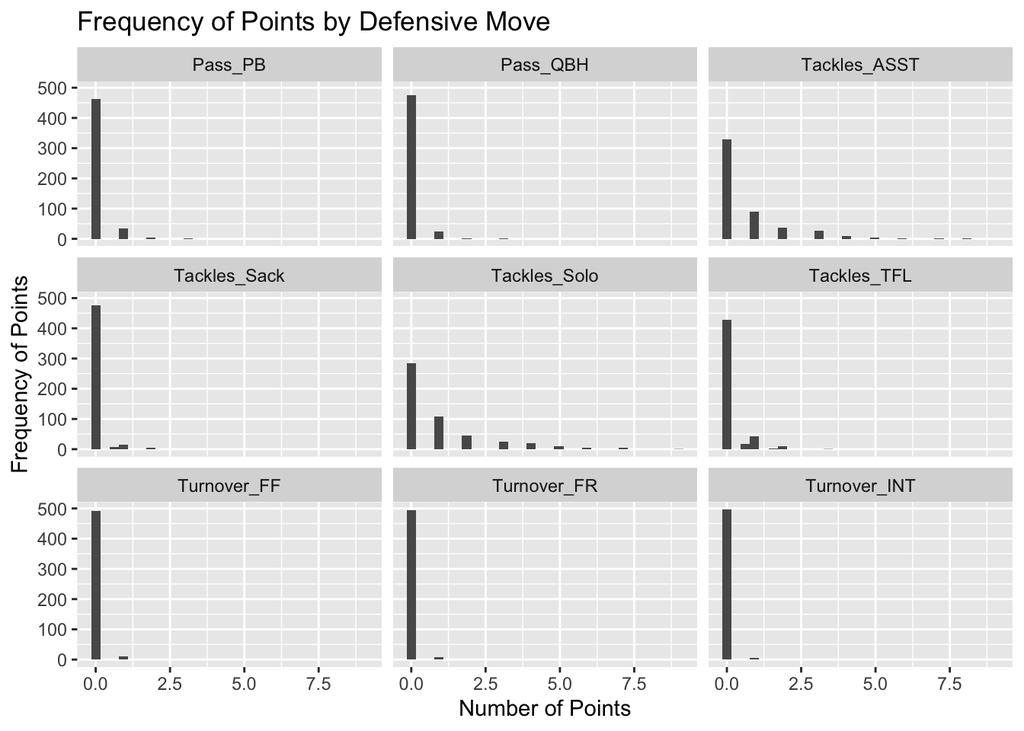

```r
ggplot(defClean2, mapping = aes(x = value, binwidth=10)) +
  geom_histogram() +
  facet_wrap(~Statistic) +
  ggtitle('Frequency of Points by Defensive Move') +
  xlab('Number of Points') +
  ylab('Frequency of Points')
```

The rare skills are the skills with the most in the `0` bin. Relative to the other skills, `Tackles_Sack`, `Turnover_FF`, `Turnover_FR`, and `Turnover_INT` are the rarest

#### 3. Did ISU have better defense against West Virginia or Kansas State?

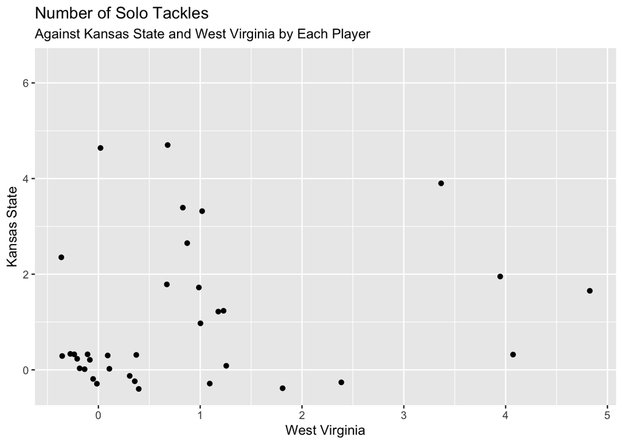

```r
defClean2 %>%
  filter(Opponent_Opponent == 'West Virginia' | Opponent_Opponent == 'Kansas State') %>%
  filter(Statistic == 'Tackles_Solo') %>%
  pivot_wider(names_from = 'Opponent_Opponent', values_from = 'value') %>%
  select(Name, 'West Virginia', 'Kansas State') %>%
  ggplot(aes(`West Virginia`, `Kansas State`)) +
  geom_jitter() +
  ggtitle('Number of Solo Tackles ', subtitle='Against Kansas State and West Virginia by Each Player')
```

It appears that the defense was better against Kansas State. There are more solo tackles overall by each player than there are for West Virginia.

#### 4. Now we’ll separate the `Hometown` column into `City` and `State` to see how many players are from each state.

```r
bioClean %>%
  separate(Hometown, sep=', ', into=c('City', 'State')) %>%
  group_by(State) %>%
  select(State) %>%
  summarize(n=n())
```

```
## # A tibble: 19 x 2
##    State         n
##    <chr>     <int>
##  1 Ariz.         4
##  2 Ark.          1
##  3 Australia     1
##  4 Calif.        3
##  5 Fla.         10
##  6 Ga.           4
##  7 Ill.          5
##  8 Iowa         35
##  9 Kan.          3
## 10 Mich.         4
## 11 Minn.         4
## 12 Miss.         1
## 13 Mo.           6
## 14 Ohio          7
## 15 Okla.         2
## 16 Pa.           1
## 17 S.D.          2
## 18 Texas         6
## 19 Wis.          6
```

It comes as no surprise that the most common home state is Iowa. Interestingly, Florida is the next highest. We also have a player from Australia according to the data.

#### 3. How does the performance of quarterback Brock Purdy relate to the performance of the ISU team?

We can figure this out by creating aggregating the overall defensive and overall offensive points into two variables. Then, we’ll join them by name and plot a scatter plot with the two variables.

```r
bioClean %>% filter(Position == 'Quarterback')
```

```
## # A tibble: 4 x 7
##   Name       Position   Height Weight Class        Hometown        Highschool
##   <fct>      <fct>       <dbl> <chr>  <fct>        <fct>           <fct>
## 1 Bouman, A… Quarterba…     78 215    Freshman     Buffalo, Minn.  Buffalo
## 2 Clark, Bl… Quarterba…     74 195    Redshirt So… West Des Moine… Dowling Cath…
## 3 Larsen, D… Quarterba…     76 219    Redshirt Fr… Gilbert, Ariz.  Queen Creek
## 4 Purdy, Br… Quarterba…     73 210    Junior       Gilbert, Ariz.  Perry
```

```r
offClean <- offClean %>% mutate_at(c(3:12), ~replace(., is.na(.), 0))
defClean <- defClean %>% mutate_at(c(3:11), ~replace(., is.na(.), 0))

offCleanPerformance <- offClean %>%
  mutate(`Offense Performance` = Rushing_ATT + Rushing_YDS + Rushing_TD + Receiving_REC + Receiving_YDS + Receiving_TD +
                      `Passing_CMP-ATT` + Passing_YDS + Passing_TD + Passing_INT) %>%
  select(Name, `Offense Performance`) %>%
  group_by(Name) %>%
  summarize(`Offense Performance` = sum(`Offense Performance`))

defCleanPerformance <- defClean %>%
  mutate(`Defense Performance` = Tackles_Solo + Tackles_ASST + Tackles_TFL + Tackles_Sack + Turnover_FF +
           Turnover_FR + Turnover_INT + Pass_QBH + Pass_PB) %>%
  select(Name, `Defense Performance`) %>%
  group_by(Name) %>%
  summarize(`Defense Performance` = sum(`Defense Performance`))

bothClean <- full_join(defCleanPerformance, offCleanPerformance)
bothClean <- bothClean %>% mutate_at(c(2:3), ~replace(., is.na(.), 0))

head(bothClean)
```

```
## # A tibble: 6 x 3
##   Name            `Defense Performance` `Offense Performance`
##   <chr>                           <dbl>                 <dbl>
## 1 Akers, Landen                      11                   127
## 2 Allen, Chase                        2                   186
## 3 Azunna, Arnold                     34                     0
## 4 Bailey, JaQuan                     13                     0
## 5 Bickham, Justin                    28                     0
## 6 Downing, Trevor                     1                     0
```

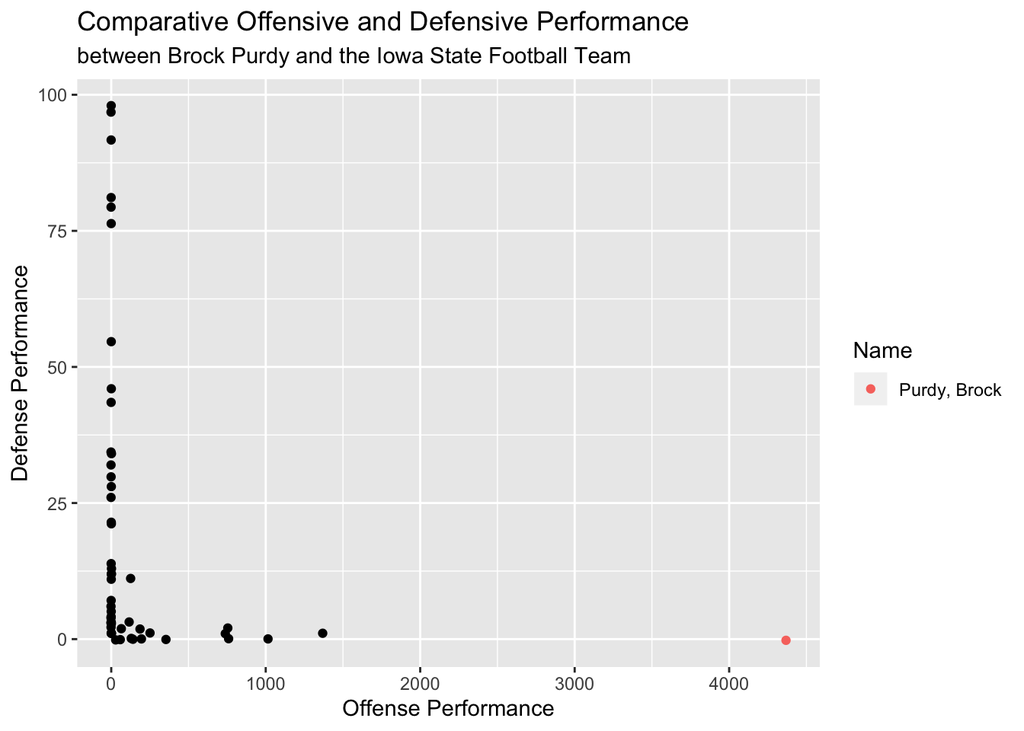

```r
ggplot() +
  geom_jitter(data = filter(bothClean, Name == 'Purdy, Brock'), aes(x = `Offense Performance`, y = `Defense Performance`, color = Name)) +
  geom_jitter(data = filter(bothClean, Name != 'Purdy, Brock'), aes(x = `Offense Performance`, y = `Defense Performance`)) +
  ggtitle('Comparative Offensive and Defensive Performance',
          subtitle = 'between Brock Purdy and the Iowa State Football Team')
```

According to this, Brock Purdy clearly has the highest offense performance of any player at over 4000, however, he has no defense score, since he is sidelined during when the team is playing defense.

#### 4.What’s the relationship between class and the number of solo tackles?

We can figure this out by joining the `bioClean` data set with the `defClean` data set. We’ll select only the data we need and call this data frame `classTackles`.

```r
classTackles <- defClean %>%
  select(Name, Tackles_Solo) %>%
  group_by(Name) %>%
  summarize(Tackles_Solo = sum(Tackles_Solo)) %>%
  left_join(bioClean) %>%
  select(Name, Tackles_Solo, Class)
head(classTackles)
```

```
## # A tibble: 6 x 3
##   Name            Tackles_Solo Class
##   <chr>                  <dbl> <fct>
## 1 Akers, Landen              9 Redshirt Senior
## 2 Allen, Chase               2 Redshirt Senior
## 3 Azunna, Arnold            18 Redshirt Senior
## 4 Bailey, JaQuan             2 Redshirt Senior
## 5 Bickham, Justin           20 <NA>
## 6 Downing, Trevor            1 Redshirt Sophomore
```

Now, let’s drop any null data just in case.

```r
classTackles <- classTackles %>% drop_na()

head(classTackles)
```

```
## # A tibble: 6 x 3
##   Name            Tackles_Solo Class
##   <chr>                  <dbl> <fct>
## 1 Akers, Landen              9 Redshirt Senior
## 2 Allen, Chase               2 Redshirt Senior
## 3 Azunna, Arnold            18 Redshirt Senior
## 4 Bailey, JaQuan             2 Redshirt Senior
## 5 Downing, Trevor            1 Redshirt Sophomore
## 6 Eisworth, Greg            37 Redshirt Senior
```

Finally, we can factor the `Class` categories in order and plot the number of solo tackles by `Class` in a bar plot. Perhaps we can expect seniors and redshirt seniors to have the highest number of tackles, because they have the most experience?

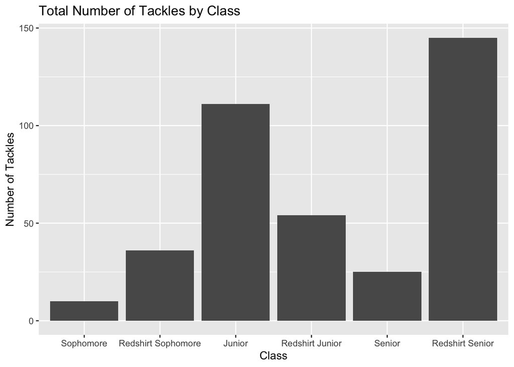

```r
classTackles$Class <- factor(classTackles$Class, c('Sophomore', 'Redshirt Sophomore', 'Junior', 'Redshirt Junior', 'Senior', 'Redshirt Senior'))

ggplot(classTackles, aes(x = Class, weight = Tackles_Solo)) +
  geom_bar() +
  ylab('Number of Tackles') +
  ggtitle('Total Number of Tackles by Class')
```